# The Elo method in chess

Filippo Pilutti

2026-10-21

**Elo method** was coined by the physics professor and excellent chess player Arpad Elo. In 1970, FIDE, the World Chess Federation, agreed to adopt the Elo Rating System.

The method works as follows. Suppose that players $i$ and $j$ match. Let $s_{i,j}$ be the **actual score** of $i$ in the match against $j$. We have that:

- $s_{i,j} = 1$ if $i$ wins;
- $s_{i,j} = 0$ if $i$ loses; and
- $s_{i,j} = 0.5$ if there is a draw.

Notice that the actual score $s_{j,i}$ of $j$ in the match against $i$ is $1 - s_{i,j}$. Let $\mu_{i,j}$ be the **expected score** of $i$ in the match against $j$. We have that:

$$\begin{array}{lll}
\mu_{i,j} & = & \frac{1}{1 + 10^{-(r_i - r_j) / \zeta}} =
\frac{10^{r_i / \zeta}}{10^{r_i / \zeta} + 10^{r_j / \zeta}} \\\\
\end{array}$$

with $r_i$ and $r_j$ the ratings of $i$ and $j$ before the match and $\zeta$ is a constant. Notice that the expected score $\mu_{j,i}$ of $j$ in the match against $i$ is $1 - \mu_{i,j}$.

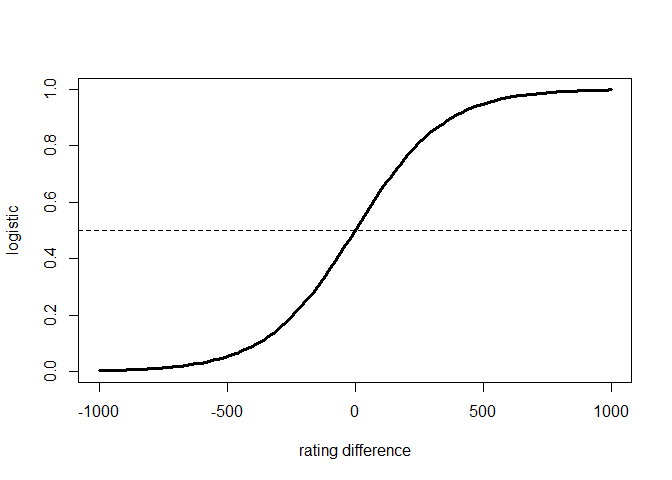

We assume that initially all player ratings are equal to 0. When players $i$ and $j$ match, the new ratings $r_i$ of $i$ and $r_j$ of $j$ are modified using the following update rule:

$$\begin{array}{lll}
r_{i} & \leftarrow & r_i + \kappa (s_{i,j} - \mu_{i,j})
\\
r_j & \leftarrow & r_j + \kappa (s_{j,i} - \mu_{j,i})
\end{array}$$

where $\kappa$ is a constant.

The Elo thesis is:

> *If a player performs as expected, it gains nothing. If it performs better than expected, it is rewarded, while if it performs poorer than expected, it is penalized.*

This challenge is ispired by [Chess ratings - Elo versus the Rest of the World](https://www.kaggle.com/c/chess#description) Kaggle competition.

## Downloads

- A CSV with outcomes of 65053 distinct chess games (White, Black and Score). The possible values for Score represent the three possible outcomes of a chess game (1=White wins, 0.5=draw, 0=Black wins). Read [details](https://www.kaggle.com/c/chess/data).

## Challenges

1. Has the White an advantage over the Black, that is, is there a first-mover advantage?
2. Write a function that computes the player point rating (1 point for wins, 0.5 points for draws, 0 points for defeats). How are point ratings distributed? Why?
3. An interesting property of Elo’s ratings is that the sum of all player ratings is always 0. Formally show this property. (Hint: use the fact that $s_{i,j} + s_{j,i}=1$ and $\mu_{i,j} + \mu_{j,i} =1$)
4. Write a function that computes the player Elo rating (set $\zeta = 400$ and $\kappa = 25$) (Hint: take advantage of the 0-sum property to optimize the code). Obserse its distribution: why is different from the point distribution? Verify the 0-sum property for Elo’s ratings
5. Are point and Elo ratings correlated? Are top Elo players overlapping with top point players?
6. Test if the number of played games has an effect on the Elo and point player ratings

### Data loading

First thing, we want to load and check the data from the given csv file.

```r
# Load data from csv and define variables types
chess <- read_csv(
  "data.csv",
  col_types = cols(
    White = col_integer(),
    Black = col_integer(),
    Score = col_double()
))
```

We want to inspect the data and check for missing values or errors.

```r
glimpse(chess)
```

```
## Rows: 65,053
## Columns: 3
## $ White <int> 73, 73, 73, 73, 73, 88, 88, 88, 154, 158, 189, 213, 370, 370, 37…
## $ Black <int> 1246, 5097, 5104, 7321, 7375, 1033, 1860, 4858, 3377, 8059, 7357…
## $ Score <dbl> 0.5, 0.5, 0.5, 1.0, 0.5, 0.5, 1.0, 1.0, 0.0, 1.0, 1.0, 0.0, 0.5,…
```

```r
# Number of missing values
colSums(is.na(chess))
```

```
## White Black Score
##     0     0     0
```

```r
# Score can only be 0, 0.5 or 1
count(chess, Score)
```

```
## # A tibble: 3 × 2
##   Score     n
##   <dbl> <int>
## 1   0   15224
## 2   0.5 28666
## 3   1   21163
```

```r
# A player should not play against himself
sum(chess$White == chess$Black)
```

```
## [1] 0
```

The data is clean, meaning no missing values and consistent with the description.

```r
# All distinct player ids, appearing as White or as Black
players <- union(chess$White, chess$Black)
length(players)
```

```
## [1] 7301
```

```r
range(players)
```

```
## [1]    1 8631
```

By inspecting the data, we find out that we have 65,053 different games on record, with 7301 distinct non-consecutive player ids, since the possible ids range from 1 to 8631.

### Challenge 1

#### Has the White an advantage over the Black, that is, is there a first-mover advantage?

Intuitively, starting first White should have an advantage over Black, but we want to empirically show it.

The idea is that, if color wouldn’t count, White and Black should both get an average of 0.5 points per game. This means that, excluding games which end in a draw, White should win as often as Black. We then want to measure how much the data differs from this scenario, to understand how much of an advantage it is moving first.

```r
outcomes <- chess |>
  count(Score) |>
  mutate(proportion = n / sum(n))
outcomes
```

```
## # A tibble: 3 × 3
##   Score     n proportion
##   <dbl> <int>      <dbl>
## 1   0   15224    0.23402
## 2   0.5 28666    0.44066
## 3   1   21163    0.32532
```

We see that White wins 32% of total games, versus the 23% of wins of the Black.

We can also compute a mean score for White.

```r
mean(chess$Score)
```

```
## [1] 0.5456474
```

Then we have that from the data it shows that White has a slight advantage over Black.

### Challenge 2

#### Write a function that computes the player point rating (1 point for wins, 0.5 points for draws, 0 points for defeats). How are point ratings distributed? Why?

```r
# Compute the player rating of a player, given its id
player_points <- function(id, data) {
  # Games played as White: the player gets "Score" points
  points_as_white <- sum(data$Score[data$White == id])
  # Games played as Black: the player gets "1 - Score" points
  points_as_black <- sum(1 - data$Score[data$Black == id])
  points_as_white + points_as_black
}

# Get all distinct player ids
players <- union(chess$White, chess$Black)

# Apply points function to all players
point_rating <- tibble(
  player = players,
  points = sapply(players, player_points, data = chess)
) |>
  arrange(desc(points))
point_rating
```

```
## # A tibble: 7,301 × 2
##    player points
##     <int>  <dbl>
##  1   4037  167.5
##  2   1286  166.5
##  3   4850  159
##  4   1594  156
##  5     64  155
##  6   1098  153.5
##  7    391  152
##  8   1512  142.5
##  9   5050  139.5
## 10   2283  134
## # ℹ 7,291 more rows
```

```r
# Safety check: total points must equal the number of games
sum(point_rating$points)
```

```
## [1] 65053
```

```r
nrow(chess)
```

```
## [1] 65053
```

Now that we have computed the points scored by each player, let’s visualize how they are distributed.

```r
summary(point_rating$points)
```

```
##    Min. 1st Qu.  Median    Mean 3rd Qu.    Max.
##    0.00    1.00    3.00    8.91    9.00  167.50
```

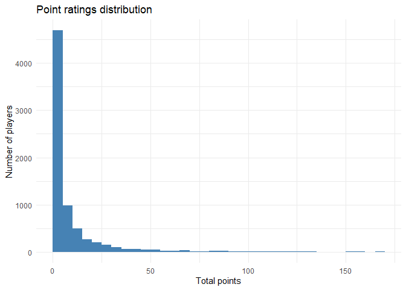

From the plot, it’s easy to see that the distribution is highly asymmetrical: median is 3, average is 8.9, and most of the players have scored less than 5 points. The main reason is that the point rating is a sum, meaning that it increases with the number of played games, reproducing its distribution. We can see that the histogram of total played games looks really similar to the one for the point rating:

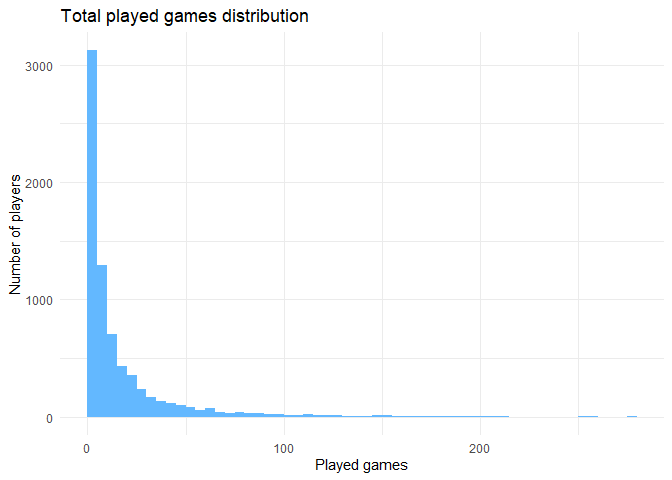

Most of the players have not played many games, and that reflects also on the points distribution.

### Challenge 3

#### An interesting property of Elo’s ratings is that the sum of all player ratings is always 0. Formally show this property. (Hint: use the fact that $s_{i,j} + s_{j,i}=1$ and $\mu_{i,j} + \mu_{j,i} =1$)

**Proof.** All players start with a rating of 0, so initially the sum of all ratings is obviously 0. Consider then a game between players $i$ and $j$: only their two ratings will change after the game, and the sum will change by

$$\kappa (s_{i,j} - \mu_{i,j}) + \kappa (s_{j,i} - \mu_{j,i})
= \kappa ((s_{i,j} + s_{j,i}) - (\mu_{i,j} + \mu_{j,i}))
= \kappa (1 - 1) = 0.$$
Hence every game leaves the total sum unchanged, and the sum of all ratings is always 0.

### Challenge 4

#### Write a function that computes the player Elo rating (set $\zeta = 400$ and $\kappa = 25$) (Hint: take advantage of the 0-sum property to optimize the code). Observe its distribution: why is different from the point distribution? Verify the 0-sum property for Elo’s ratings

It’s not possible to write a function that computes the Elo of a single player, as I did with the points rating before, since Elo computation needs the current Elo of both players for every single match. So I will write a function that computes it for all the players, game by game, in chronological order.

```r
# Elo function
elo_rating <- function(data, zeta = 400, kappa = 25) {

  # Create a vector with one entry per possible id
  rating <- rep(0, max(data$White, data$Black))

  for (k in 1:nrow(data)) {
    i <- data$White[k]
    j <- data$Black[k]
    # Expected score of white, using rating values from before the game
    mu <- 1 / (1 + 10^(-(rating[i] - rating[j]) / zeta))
    # Using zero-sum property, Black gets opposite rating change than White
    delta <- kappa * (data$Score[k] - mu)
    rating[i] <- rating[i] + delta
    rating[j] <- rating[j] - delta
  }

  # We keep the ids of only players that actually played
  players <- union(data$White, data$Black)
  tibble(player = players, elo = rating[players]) |>
    arrange(desc(elo))
}
```

```r
elo <- elo_rating(chess)
elo
```

```
## # A tibble: 7,301 × 2
##    player    elo
##     <int>  <dbl>
##  1   7848 326.95
##  2   3344 274.14
##  3   7715 271.45
##  4   2295 270.84
##  5    158 269.73
##  6   8121 260.53
##  7   2479 256.30
##  8   2581 245.68
##  9   8287 245.37
## 10     64 237.61
## # ℹ 7,291 more rows
```

```r
summary(elo$elo)
```

```
##     Min.  1st Qu.   Median     Mean  3rd Qu.     Max.
## -146.456  -22.873   -6.005    0.000   12.476  326.950
```

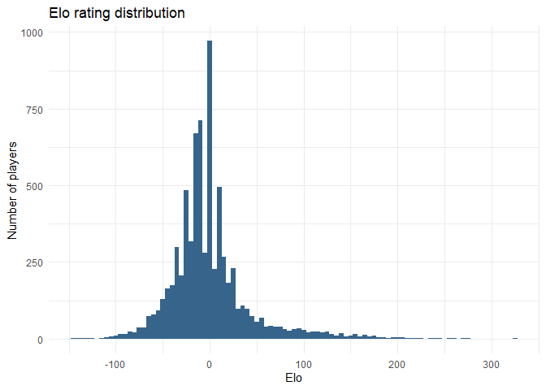

Unlike the points distribution, here we have a peak on value 0, and two tails toward negative values and high positive values. This is because Elo is not cumulative: it does not accumulate while playing more. A player gains Elo points only by behaving better than predicted and loses them by doing worse.

Main characteristics:

- There are negative values and the mean is exactly 0
- There is a peak at around 0: many players have very few games on record, and every game barely moves their rating.
- The tails are composed by players who played a lot of games. Only with lots of games, the rating has the time to significantly move away from 0.

Let’s verify the 0-sum property:

```r
sum(elo$elo)
```

```
## [1] 7.638334e-13
```

```r
all.equal(sum(elo$elo), 0)
```

```
## [1] TRUE
```

The sum is not exactly 0, but a really small number (7.638334e-13). This is due to floating-point rounding errors accumulated over 65,053 updates. Using all.equal to check for the equality returns TRUE, since it allows for a very small tolerance.

### Challenge 5

#### Are point and Elo ratings correlated? Are top Elo players overlapping with top point players?

First thing, we create a table containing both ratings for every player, and we visualize the data.

```r
ratings <- inner_join(point_rating, elo, by = "player")
ratings
```

```
## # A tibble: 7,301 × 3
##    player points    elo
##     <int>  <dbl>  <dbl>
##  1   4037  167.5 181.46
##  2   1286  166.5 176.31
##  3   4850  159   158.48
##  4   1594  156   132.35
##  5     64  155   237.61
##  6   1098  153.5 164.40
##  7    391  152   213.81
##  8   1512  142.5 140.40
##  9   5050  139.5 203.46
## 10   2283  134   222.23
## # ℹ 7,291 more rows
```

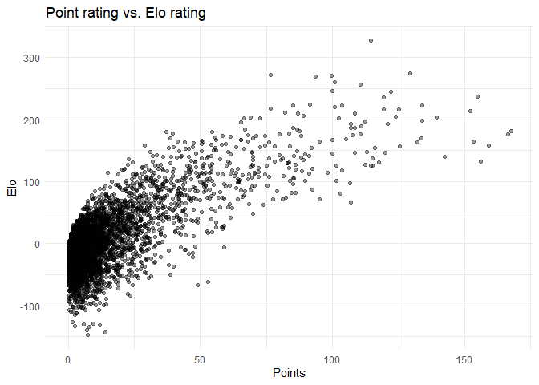

From the scatterplot, we can see that there is a positive correlation, but an imperfect one. Players with high points rating usually have a high Elo, but for example, players with the highest Elos are not those with the most points. Close to the origin, the Elo rating of players with few points ranges between -150 and +100, so we see that for the same amount of points, Elo ratings can vary considerably.

Let’s quantify the overlap between top Elo players and top points players.

```r
# Function to measure the number of players in common between the top k players
# of the two rankings.
top_overlap <- function(k) {
  top_points <- head(point_rating$player, k)
  top_elo <- head(elo$player, k)
  length(intersect(top_points, top_elo))
}

# Check the overlap in top 10, 50, 100, 500, 1000
k <- c(10, 50, 100, 500, 1000)
tibble(
  k = k,
  overlap = sapply(k, top_overlap),
  percentage = (overlap / k) * 100
)
```

```
## # A tibble: 5 × 3
##       k overlap percentage
##   <dbl>   <int>      <dbl>
## 1    10       1       10
## 2    50      26       52
## 3   100      52       52
## 4   500     372       74.4
## 5  1000     694       69.4
```

There is only one player in both top 10 rankings. The number of common players increases with k, but the percentage stays far from 100%.

### Challenge 6

#### Test if the number of played games has an effect on the Elo and point player ratings

```r
# We add the number of games played to the ratings table
ratings <- ratings |>
  inner_join(games_played, by = "player")
ratings
```

```
## # A tibble: 7,301 × 4
##    player points    elo games
##     <int>  <dbl>  <dbl> <int>
##  1   4037  167.5 181.46   272
##  2   1286  166.5 176.31   270
##  3   4850  159   158.48   280
##  4   1594  156   132.35   276
##  5     64  155   237.61   258
##  6   1098  153.5 164.40   252
##  7    391  152   213.81   255
##  8   1512  142.5 140.40   257
##  9   5050  139.5 203.46   216
## 10   2283  134   222.23   211
## # ℹ 7,291 more rows
```

Now we have a table that for each player it shows both ratings and how many games they played. Let’s then visualize how the two ratings correlate to number of played games.

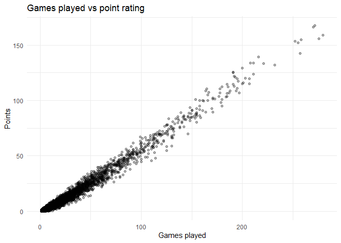

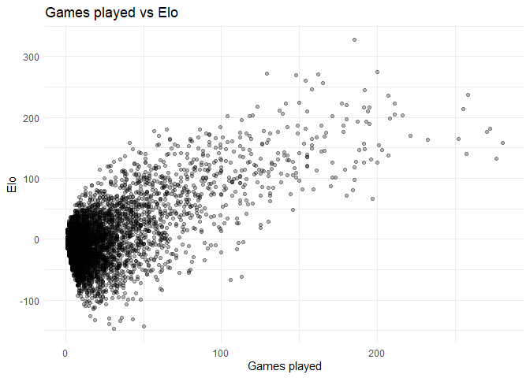

We have two very different plots.

In the points plot, the players are almost on a straight line. More games means more points, almost without exceptions.

The Elo plot looks very similar to the Points vs Elo plot, that is because we have just seen that there is basically a linear correlation between games and points. We see that who played less, has a sparse Elo above and below 0, while who played more (more than 100 games), is almost always above 0.

In conclusion, we can see that the number of played games has an effect on both ratings, but with a big difference in intensity: really strong for points rating, weak for Elo, and concentrated on the most active players. We can then conclude that Elo rating is a a more appropriate measure of relative strength of a chess player, since points rating is highly influenced by the number of played games.